# Panel/Longitudinal Data and its Associated Regression Practices

Author

Affiliation

[Cole Brookson](https://github.com/colebrookson)

Epidemiology of Microbial Disease

Published

December 16, 2025

Abstract

Keywords

panel data, fixed effects models, multilevel models, random effects, longitudinal data, clustered data, R, Julia,

# Introduction

In all domain fields there are different forms of multi-dimensional data. Often, this multi-dimensionality will manifest as the data having “structure”, namely co-variance, in some way. It’s useful to refer to the levels at which the data are grouped. It’s often the case that observations at the first level of complexity are clustered into groups of some kind at a second level. While it’s true that there can be arbitrarily many structures, we’ll focus on two-level structures. There are multiple examples of these kinds of structures, but one common two-level structure is referred to as **panel data**[^1]. Panel data occur across all disciplines, and typically involve making repeated observations of some set of groups of interest, say individuals of a given social class through time. Typically we say that an observation of a panel, $Y_{it}$ is observed for all objects/individuals/etc. $i=1,...,N$ across time periods $t = 1,...,T$.

Performing regression on these data requires careful considerations of the types of effects baked into the data structures, their representation in our statistical models, and correct inference on the results. In this guide we’ll discuss the benefits of panel data, different types of effects they contain, a suite of approaches to deal with them, when to use each approach, and how the approaches can be implemented in various the R programming language. Note that this guide assumes that readers are familiar with OLS regression, the concepts of fixed and random effects in the classical statistical sense, and ideally have at least heard of panel data before.

**Panel Regression is Just Normal Regression, Don’t Worry**

Due to the fact that economists (mostly) use the term “panel regression” as a single noun and not as a noun with a modifying adjective, readers could be forgiven for thinking that somehow panel regression is some special unique form of regression, developed by econometricians for their uniquely challenging problems. This is not the case. The term “panel regression” is simply a term used to encompass all of the various ways (some of which are discussed here) that one may go about performing regression on panel data. It is not one, or even a specific form of regression, but an umbrella term. Additionally, “panel” data is a term rarely used outside of the social sciences, and other disciplines are probably more familiar with data of this type (described below) being referred to as “repeated-measures” data or “longitudinal” data.

## What is Panel Data?

**Panel data** importantly tracks the same groups over-time, which is what distinguishes it from cross-sectional data alone. It can take the form of repeated measurements on individuals (where each individual serves as it’s own group, $i$) through time, measures of groups of individuals (e.g. prevalence of a particular disease, see Figure 1) through time, etc. The data can be balanced or unbalanced similar to other data types wherein missingness can occur in one or both dimensions of the data, and a common sub-type of panel data is large numbers of $N$ groups, but short timeseries $T$ across all groups. For example, a large number of companies might be observed for performance metrics quarterly for only a few years.

```
flowchart TB
    Title["<b>PANEL DATA STRUCTURE</b><br/>Multiple entities observed over multiple time periods"]

    EntitiesTitle["<b>Cross-Sectional Dimension</b><br/>e.g. Prevalence of a disease across counties"]
    TimeTitle["<b>Time Dimension</b><br/>e.g. Through years"]

    subgraph Entities[" "]
        direction LR
        E1["<b>Prevalence in county 1</b>"]
        E2["<b>Prevalence in county 2</b>"]
        E3["<b>Prevalence in county 3</b>"]
        EDots["<b>⋮</b>"]
        EN["<b>Prevalence in county N</b>"]
    end

    subgraph Time[" "]
        direction LR
        T1["<b>2020</b>"]
        T2["<b>2021</b>"]
        T3["<b>2022</b>"]
        TDots["<b>⋮</b>"]
        TT["<b>2025</b>"]
    end

    DataTitle["<b>Data Matrix: yᵢₜ</b>"]

    subgraph Data[" "]
        direction LR
        R1["y₁₁, y₁₂, y₁₃, ..., y₁ₜ"]
        R2["y₂₁, y₂₂, y₂₃, ..., y₂ₜ"]
        R3["y₃₁, y₃₂, y₃₃, ..., y₃ₜ"]
        RDots["⋮   ⋮   ⋮   ⋱   ⋮"]
        RN["yₙ₁, yₙ₂, yₙ₃, ..., yₙₜ"]
    end

    Title --> EntitiesTitle
    Title --> TimeTitle
    EntitiesTitle --> Entities
    TimeTitle --> Time
    Entities --> DataTitle
    Time --> DataTitle
    DataTitle --> Data

    Summary["Each cell yᵢₜ represents the observation for county i at time t<br/>Total observations = N counties × T time periods"]

    Data --> Summary

    style Title fill:#2563eb,stroke:#1e40af,stroke-width:3px,color:#fff
    style EntitiesTitle fill:#60a5fa,stroke:#3b82f6,stroke-width:2px,color:#fff
    style TimeTitle fill:#60a5fa,stroke:#3b82f6,stroke-width:2px,color:#fff
    style DataTitle fill:#f59e0b,stroke:#d97706,stroke-width:2px,color:#fff
    style Entities fill:#dbeafe,stroke:#3b82f6,stroke-width:2px
    style Time fill:#dbeafe,stroke:#3b82f6,stroke-width:2px
    style Data fill:#fef3c7,stroke:#f59e0b,stroke-width:2px
    style Summary fill:#d1fae5,stroke:#10b981,stroke-width:2px
```

Figure 1: Illustration of panel data.

Regardless of data quality, variables in panel data can be related at more than one level in hierarchy, with *different relationships at those different levels*. Suffice it to say that an important component of panel data is that there are often effects that occur at level 1, which we can term **“within-group” effects**[^2]. These are different than the effects that might be observed at level 2 which might be “contextual” or which we can term **“between-group” effects**[^3]. A visualization of this is provided in Figure 2.

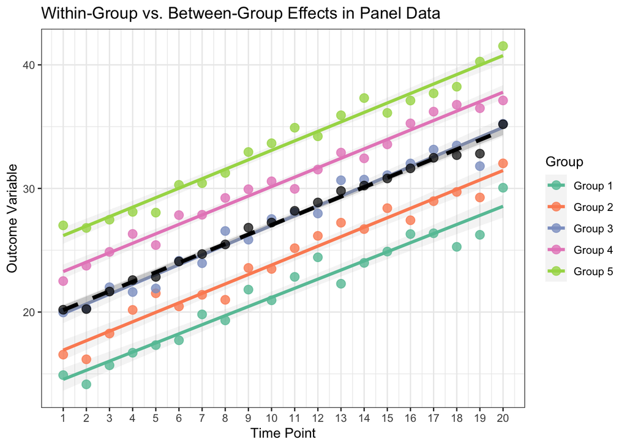

Figure 2: In these simulated data, each coloured line represents one group’s outcome trajectory across 20 time points. The within-group effect is visible in the slopes of individual trajectories, showing that each group experiences outcome changes over time relative to its own baseline. The between-group effect is visible in the vertical separation between lines, demonstrating that some groups maintain distinct average outcome levels throughout the observation period. The dashed black line represents the overall mean trajectory across all groups.

```r
# Load required libraries
library(ggplot2)
library(dplyr)

# Set random seed for reproducibility
set.seed(42)

# Generate synthetic data for multiple groups
n_groups <- 5
n_timepoints <- 20
time_points <- 1:n_timepoints

# Define different slopes for each group (they average to approximately 0)
group_slopes <- c(0.8, 0.8, 0.8, 0.8, 0.8)

# Create data frame with distinct between-group and within-group patterns
data_list <- list()

for (group_id in 1:n_groups) {
    # Each group has a different baseline (between-group effect)
    group_mean <- 10 + (group_id * 3)

    # Each group has its own unique slope over time
    group_slope <- group_slopes[group_id]

    for (t in time_points) {
        # Within-group variation: unique slope for each group
        within_effect <- group_slope * t
        # Add random noise
        noise <- rnorm(1, mean = 0, sd = 0.8)

        outcome_value <- group_mean + within_effect + noise

        data_list[[length(data_list) + 1]] <- data.frame(
            Group = paste0("Group ", group_id),
            Time = t,
            Outcome = outcome_value
        )
    }
}

# Combine into single data frame
df <- do.call(rbind, data_list)

# Calculate overall mean at each timepoint
overall_means <- df %>%
    group_by(Time) %>%
    summarise(Mean_Outcome = mean(Outcome))


# Create the plot
plot <- ggplot() +
    # Individual group trajectories
    geom_smooth(
        data = df, aes(x = Time, y = Outcome, colour = Group, group = Group),
        linewidth = 1.2, alpha = 0.1, method = "lm"
    ) +
    geom_point(
        data = df, aes(x = Time, y = Outcome, colour = Group),
        size = 3, alpha = 0.8
    ) +
    # Overall mean trajectory
    geom_smooth(
        data = overall_means, aes(x = Time, y = Mean_Outcome),
        linetype = "dashed", linewidth = 1.5, colour = "black", method = "lm"
    ) +
    geom_point(
        data = overall_means, aes(x = Time, y = Mean_Outcome),
        size = 3, colour = "black", alpha = 0.7
    ) +
    # Formatting
    scale_x_continuous(breaks = time_points) +
    scale_colour_brewer(palette = "Set2") +
    labs(
        title = "Within-Group vs. Between-Group Effects in Panel Data",
        x = "Time Point",
        y = "Outcome Variable",
        colour = "Group"
    ) +
    theme_bw()
plot
```

In this guide we’ll go over the formalism behind extracting these various kinds of differences from panel data, including an overview of different methods and approaches available.

# Methods

## Theoretical Intuition

As we’ve established by now, panel data (or whatever we wish to call it, “longitudinal” or “repeated measures”) consists of repeated observations on the same groups over time, denoted as $y_{it}$ for group $i = 1, ..., N$ at time $t = 1, ..., T$. The attentive reader may notice that this leads to an obvious challenge in the form of **non-independence**[^4]. This problematic correlation structure requires special consideration as it creates both inferential challenges (affecting the precision of our estimates) and identification challenges (affecting the consistency and interpretation of our estimates).

To get a better sense of what this means under the hood we can formalize this notion and look to what the formalism guides us to by way of solution. Let’s say that the observed outcome in a panel data setting can be decomposed as:

$$\begin{equation}
y_{it} = \boldsymbol{\beta}x^T_{it} + \varepsilon_{it}
\end{equation}$$
where $y_{it}$ is the observed value of some outcome variable in group $i$ at time $t$. We also assume that there is a set of $K$ explanatory variables $x_{it}$ which are observed as well, and therefore a set of $K$ coefficeints $\mathbf{\beta}$, which are estimated. There is then an error term $\varepsilon_{it}$, which is assumed to have mean 0, and contains multiple components that reflect the hierarchical nature of the data:

$$\varepsilon_{it} = \alpha_i + u_{it}$$

The component $\alpha_i$ represents the group-specific effect, which is time-invariant and captures all systematic, but unobserved characteristics of group $i$ that remain constant over the observation period. The variance of that effect, $Var(\alpha_i) = \tau^2$ quantifies the amount of variation in the outcome that is attributable to differences between groups. Additionally, $u_{it}$ is a random variable that is independent and identically distributed (i.i.d.) with mean 0 and some variance. It represents the idiosyncratic error that varies across both groups and time periods, capturing random variation specific to group $i$ at time $t$.

This will become important later, but typically since we wish to characterize the within-group and between-group variation, we can account for variation **within** groups by any set of time-dependent covariates $x_{it}$ and our error term $\varepsilon_{it}$. On the other hand, variation **between** groups is accounted for by the covariates but also the group-specific effects, $\alpha_i$.

**How do we treat group-specific effects?**

Central to this guide is the fact that one can assume that the group-specific effect $\alpha_i$ can take the form of a **random effect** or a **fixed effect**.

The challenge in using standard regression approaches arises due to the that fact that for any two observations from the same group $i$ at different time periods $t$ and $s$, the error terms are correlated:

$$\text{Cov}(\varepsilon_{it}, \varepsilon_{is}) = \text{Var}(\alpha_i) \neq 0 \quad \text{for } t \neq s$$

This correlation exists because both observations share the same group-specific effect $\alpha_i$. This is known as the **intraclass correlation** or **within-cluster correlation**, which can be expressed as:

$$\begin{equation}
\rho = \frac{\text{Var}(\alpha_i)}{\text{Var}(\alpha_i) + \text{Var}(u_{it})} = \frac{\tau^2_{\alpha}}{\tau^2_{\alpha} + \sigma^2_u}
\end{equation}$$

This quantity represents the proportion of total variance that is attributable to differences between groups rather than within-group variation over time. The presence of positive intraclass correlation has important consequences for inference. Standard ordinary least squares (OLS) methods assume independent observations and will understate the true standard errors when within-group correlation is present, leading to overconfident inference and inflated Type I error rates.

A second and often more serious problem is related to the **heterogeneity bias**[^5] of the system. This challenge arises when the group-specific effect $\alpha_i$ is correlated with the observed predictors. If $\text{Cov}(\mathbf{x}_{it}, \alpha_i) \neq 0$, then the group-specific effect represents an omitted variable that is correlated with the included predictors, causing **omitted variable bias**. In this case, the result of this troublesome correlation is that the OLS estimator will be inconsistent:

$$\mathbb{E}[\hat{\beta}_{OLS}] = \boldsymbol{\beta} + \text{bias}$$

The bias arises because standard OLS incorrectly attributes variation in $y$ that is actually caused by $\alpha_i$ to the observed predictors $\mathbf{x}_{it}$, since these are correlated with $\alpha_i$. This endogeneity problem is distinct from the correlation problem discussed above, because even if we could somehow compute the correct standard errors, our point estimates would still be biased and inconsistent in the presence of endogeneity.

Now that we have a sense of what makes panel data different and why we can’t just use standard OLS to answer our questions, what **do** we actually do?? In the rest of this Methods section, we outline some of the options that exist to effectively do regression on panel data.

## Option 1: Fixed-effects models

Fixed-effects models have been the “gold-standard” to deal with panel data for some time in the Economics literature, but in the interest of not burrying the lead, we do not recommend the use of fixed-effects models (FE models) as the default for panel data. However, due to their commonality, we outline here their formulation and use, along with important caveats.

The use of a FE model stems from the challenge we identified earlier as heterogeneity bias. If a group-specific effect $\alpha_i$ is correlated with any explanatory variables, we cannot treat it as a random variable in the classic sense (but see Section 2.3). Therefore, we simply do not attempt to measure the variation between groups (for which we would need to use a group-specific effect, $\alpha_i$). The fixed effects model, using the notation of Bell and Jones (2015) is then defined as

$$\begin{equation}
y_{it} = \sum_{j=1}^N \beta_{0j} D_{ji} + \mathbf{\beta_1}\mathbf{x_{it}} + u_{it}
\end{equation}$$

where $D_i$ is a dummy variable that equals one for all observations from group $i$ and zero otherwise. In this formulation, each group receives its own intercept $\beta_{0i}$, which captures that group’s specific effect $\alpha_i$.

In this formulation, we’ve explicitly dealt with our problem by controlling for all time-invariant group-specific characteristics. By including these group-specific intercepts, the model accounts for all time-invariant characteristics of each group, whether observed or unobserved, eliminating the problematic correlation $\text{Cov}(\mathbf{x}_{it}, \alpha_i) \neq 0$.

To see how this works, recall that our concern was the correlation between the group-specific effect $\alpha_i$ and our covariates. In the fixed effects specification above, $\alpha_i$ is no longer part of the error term—it has been absorbed into the estimated parameters $\beta_{0i}$. The residual $u_{it}$ now contains only the idiosyncratic, time-varying component of the error, which by assumption is uncorrelated with the covariates: $\text{Cov}(\mathbf{x}_{it}, u_{it}) = 0$. This eliminates heterogeneity bias because we have explicitly modeled the source of the endogeneity.

### The Within Transformation

While the dummy variable approach is conceptually straightforward, estimating $N$ separate intercept parameters is computationally intensive, especially with large datasets. A mathematically equivalent but more efficient approach is the **within transformation** (also called the **within estimator** or **mean-differencing**), which is standard practice.

To derive this, we begin by taking the time-average of our original model specification for each group:

$$\bar{y}_i = \boldsymbol{\beta}\bar{\mathbf{x}}^T_i + \alpha_i + \bar{u}_i$$

where $\bar{y}_i = \frac{1}{T}\sum_{t=1}^T y_{it}$ is the within-group mean over time, and similarly for the other variables. Subtracting this group-specific mean equation from the original observation-level equation eliminates the time-invariant $\alpha_i$:

$$\begin{align}
y_{it} - \bar{y}_i &= \boldsymbol{\beta}(\mathbf{x}_{it} - \bar{\mathbf{x}}_i)^T + (u_{it} - \bar{u}_i) \\
\tilde{y}_{it} &= \boldsymbol{\beta}\tilde{\mathbf{x}}^T_{it} + \tilde{u}_{it}
\end{align}$$

where the tilde ($\tilde{\phantom{x}}$) denotes deviation from the group-specific mean. This is known as the **within transformation** or **demeaning** transformation. Because $\alpha_i$ is constant within each group, it equals its own mean and therefore disappears: $\alpha_i - \bar{\alpha}_i = \alpha_i - \alpha_i = 0$.

The fixed effects estimator can then be obtained by applying OLS to this transformed equation:

$$\begin{equation}
\tilde{y}_{it} = \boldsymbol{\beta}\tilde{\mathbf{x}}^T_{it} + \tilde{u}_{it}
\end{equation}$$

This formulation makes clear what the fixed effects estimator actually does: it identifies $\boldsymbol{\beta}$ using only **within-group variation over time**. Any variation between groups is completely removed. The FE estimator answers the question: “When a group’s $x$ value changes over time, how does its $y$ value change?” The important note to stress here is that it cannot answer questions about differences between groups with different levels of $x$.

**The Hausman Test**

Even among practioners who favour FE approaches, random effects (RE) are preferred when this heterogeneity bias does not exist. Many people will use the Hausman Test (Hausman 1978)to test for whether or not such bias exists by checking to see if a between-group effect is significantly biasing an estimate of the within effect, but this is not typically a recommended approach to determininng whether a fixed or random effect should be preferred (Fielding 2004).

Importantly should all the considerations of the FE model be taken on and dismissed, the FE model is not “bad” in any way. Should one only care about the within-group effects, this approach can be very powerful, especially since many would argue that in this formulation, $\beta_1$ can be taken as a “causal” effect. However, this notion is in opposition to the opinion of Bell and Jones (2015), which we agree with, that

> “We take it as axiomatic that we need both [within-group] and [between-group] associations to understand the whole of ‘what is going on’.”

Note that despite this opinionated denouncing of the FE model, we do describe how to implement it below 😁.

## Option 2: Random-effects models

The rest of this methods section will focus on (our) preferred method which is the various form that a random effects model can take. Random effects models take a fundamentally different approach to panel data than fixed effects models. Rather than controlling out all group-specific variation, RE models explicitly partition the total variance into components at different levels of the hierarchy. However, the standard formulation of RE models is susceptible to heterogeneity bias, which has led many researchers to abandon them in favor of FE models. As we will show, this abandonment is premature—a correctly specified RE model can eliminate heterogeneity bias while retaining substantial advantages over FE approaches.

### The Standard Random Effects Specification

The basic random effects model treats the group-specific effect $\alpha_i$ as a random variable drawn from a distribution, rather than as a parameter to be estimated. The model is:

$$\begin{equation}
y_{it} = \beta_0 + \beta x_{it} + \beta_z z_i + \alpha_i + u_{it}
\end{equation}$$

where $x_{it}$ is a time-varying covariate, $z_i$ represents a time-invariant covariate (such as gender or country of origin), and the error components are assumed to be normally distributed:

$$\begin{align}
\alpha_i &\sim N(0, \tau^2_\alpha) \\
u_{it} &\sim N(0, \sigma^2_u)
\end{align}$$

with $\text{Cov}(\alpha_i, u_{it}) = 0$ for all $i$ and $t$. This specification has several advantages in that it accounts for the within-group correlation structure, provides correct standard errors, and allows us to estimate the effects of time-invariant variables. Moreover, by assuming that $\alpha_i$ comes from a common distribution with variance $\tau^2_\alpha$, the model provides substantively interesting information about how much variation exists between groups.

### The Exogeneity Assumption and Its Violation

As we’ve now stated a few times, the RE model assumes no heterogeneity bias. Formally, this requires:

$$\begin{equation}
\text{Cov}(x_{it}, \alpha_i) = 0 \quad \text{and} \quad \text{Cov}(x_{it}, u_{it}) = 0
\end{equation}$$

When this assumption holds, the RE estimator is consistent and efficient. However, in many—perhaps most—applications with panel data, this assumption is violated due to the substantive feature of most data, that **time-varying covariates often have both within-group and between-group effects that differ in magnitude**, as mentioned in the Introduction.

To understand this, we can think of any time-varying covariate $x_{it}$ being decomposable into two components:

$$\begin{equation}
x_{it} = \bar{x}_i + (x_{it} - \bar{x}_i)
\end{equation}$$

where $\bar{x}_i = \frac{1}{T}\sum_{t=1}^T x_{it}$ is the group-specific mean (the **between component**), and $(x_{it} - \bar{x}_i)$ is the deviation from that mean (the **within component**). These two components can have substantively different relationships with the outcome:

**As a reminder, what do we mean by within-group vs. between-group effects?**

- The **within effect** captures how changes in $x$ over time within a group relate to changes in $y$: “When this group’s $x$ value increases, how does its $y$ value change?”
- The **between effect** captures how groups with different average levels of $x$ differ in their average levels of $y$: “How do groups with higher average $x$ differ from groups with lower average $x$?”

Let’s make this more concrete with an example. Say we care about income inequality and health outcomes. In studying this relationship at the country level, a country experiencing an increase in inequality over time (within effect) may show different patterns than the differences between historically high-inequality and low-inequality countries (between effect).

When the standard RE model includes only $x_{it}$ with a single coefficient $\beta$, it implicitly assumes that the within and between effects are equal. If they differ, $\beta$ becomes an uninterpretable weighted average of the two effects. The unaccounted-for between effect becomes part of the group-specific residual $\alpha_i$, creating the problematic correlation $\text{Cov}(x_{it}, \alpha_i) \neq 0$ that violates the exogeneity assumption. This is **heterogeneity bias**—the same issue that motivated the use of fixed effects models.

### The Random Effects Within-Between (REWB) Solution

The solution to heterogeneity bias in RE models is conceptually straightforward: explicitly model both the within and between effects rather than constraining them to be equal. This clever approach, originally proposed by Mundlak (1978) and refined by subsequent researchers, involves including the group-specific mean of each time-varying covariate as an additional predictor.

The **Mundlak formulation** augments the standard RE model as follows:

$$\begin{equation}
y_{it} = \beta_0 + \beta_W x_{it} + \beta_C \bar{x}_i + \beta_z z_i + \alpha_i + u_{it}
\end{equation}$$

where $\bar{x}_i$ is the group-specific mean for the time-varying covariate. In this specification: - $\beta_W$ represents the within effect (controlling for $\bar{x}_i$) - $\beta_C$ represents the “contextual effect,” the difference between the between and within effects

While the Mundlak formulation is useful, we prefer the **within-between formulation**, which makes the separation of effects more explicit and reduces multicollinearity by centering the time-varying covariate:

$$\begin{equation}
y_{it} = \beta_0 + \beta_W(x_{it} - \bar{x}_i) + \beta_B\bar{x}_i + \beta_z z_i + \alpha_i + u_{it}
\end{equation}$$

where $\beta_W$ is the **within effect**, which means the effect of a group’s deviation from its own mean. Then, $\beta_B$ is the **between effect** which is the effect of a group’s average level over time. Finally, we have $\alpha_i \sim N(0, \tau^2_\alpha)$ and $u_{it} \sim N(0, \sigma^2_u)$ with the same distributional assumptions as before.

This is the **Random Effects Within-Between (REWB) model**, which we advocate as the default approach for panel data analysis.

### Why REWB Eliminates Heterogeneity Bias

The REWB model eliminates heterogeneity bias through a simple but powerful mechanism: by group-mean centering the time-varying covariate, we ensure that $\text{Cov}[(x_{it} - \bar{x}_i), \alpha_i] = 0$ by construction. The centered variable $(x_{it} - \bar{x}_i)$ has a mean of exactly zero within each group, so it cannot be correlated with the group-specific effect $\alpha_i$, which is constant within groups.

Similarly, the between component $\bar{x}_i$ is a time-invariant characteristic of group $i$, treated like any other time-invariant variable. Any correlation between $\bar{x}_i$ and $\alpha_i$ is no more problematic than correlation between other time-invariant variables and $\alpha_i$—it does not bias the within effect estimate $\beta_W$.

Critically, Mundlak (1978) proved that **when the model is properly specified in this way, the within effect estimate** $\beta_W$ from the REWB model is identical to the estimate from a fixed effects model. This is a really central concept and shows us that the REWB model therefore provides all the protection against heterogeneity bias that FE offers, while adding substantial additional information.

In the following sections, we demonstrate the REWB approach using our example dataset and show how it provides richer substantive insights than alternative approaches.

# Implementation

In this section we demonstrate how to fit both fixed effects and random effects within-between models using some simulated data. To try and illustrate the various advantages of different methods for panel data, we step through the different options discussed above. Since FE models are so common, we demonstrate how to fit an FE model first to see what it can tell us, then build up to a REWB model to hopefully demonstrate what additional insights become available. Throughout, we focus on interpretation of results and understanding what each model tells us about our data. This means we do not spend much time at all on diagnostics since diagnostic procedures are covered in detail in other guides. However, we would like to note that they should always be performed before drawing conclusions.

**Diagnostics Are Essential !!**

As with any regression analysis, proper diagnostic checking is crucial before interpreting results. This includes examining residuals for normality and homoscedasticity, checking for influential observations, and verifying that model assumptions hold. We omit these checks here for brevity, but they should always be performed in practice. See the mixed-effects models guide for comprehensive diagnostic procedures that apply equally to panel data models.

Throughout this section we develop a single concrete example involving **simulated** student achievement data. Let’s imagine we are studying how school funding relates to student test scores, with repeated observations of the same schools over several years. Importantly, our schools differ in a time-invariant way—some are public schools and some are private schools—which allows us to demonstrate how one might go about treating this fact statistically. This example nicely illustrates the distinction between within-school effects (what happens when a school’s funding changes over time), between-school effects (how schools with different funding levels compare to each other), and the role of time-invariant characteristics that fixed effects models cannot address.

## R Implementation Options and Setup

Before diving in, let’s briefly survey the available tools for panel data analysis in R. The R package ecosystem offers several excellent packages, each with particular strengths.

For **fixed effects models**, the most popular choice is the `plm` package (Croissant and Millo 2008), which was designed specifically for panel data and offers a wide range of estimation methods, diagnostic tests, and convenience functions. The package handles both balanced and unbalanced panels efficiently and provides straightforward syntax for panel data structures. An alternative is the `fixest` package, which is particularly fast for large datasets and offers excellent support for high-dimensional fixed effects. For those already familiar with mixed-effects models, the `lme4` package (Bates et al. 2014) can also fit fixed effects models by including group indicators as factors in the model formula, though this approach is less efficient for large numbers of groups.

For **random effects models**, including the REWB specification we advocate, the `lme4` package is the standard tool in R. It provides robust and efficient estimation of mixed-effects models with flexible random effects structures. The package’s `lmer()` function handles the random effects naturally and provides excellent tools for inference. The `nlme` package is an older alternative that offers additional features for modeling complex correlation structures, though `lme4` is generally preferred for standard panel data applications. Some researchers also use the `plm` package for random effects estimation, particularly when they want to keep all panel data analysis within a single package framework.

Let’s load the packages we’ll use for our examples:

```r
# Load required packages
library(plm) # For fixed effects models
library(lme4) # For random effects REWB models
library(dplyr) # For data manipulation
library(ggplot2) # For visualization
library(gridExtra) # For arranging plots

# Set seed for reproducibility
set.seed(42)
```

## Simulated School Data

To most clearly demonstrate what each modeling approach can and cannot tell us, we use a single dataset throughout this section. We simulate data for forty schools observed over twelve years, where schools differ in both their funding levels and in whether they are public or private institutions.

In our simulation, we create several important features. Changes in funding within schools over time have a modest effect on test scores (the within effect, which we set to 0.6 points per thousand dollars). However, schools with higher average funding across all years show substantially higher test scores (the between effect, which we set to 1.8 points per thousand dollars). This difference might arise because historically well-funded schools have accumulated advantages beyond just current funding—better facilities, experienced teachers, engaged communities. Additionally, private schools score higher on average than public schools (we set this effect to 10 points), even after accounting for funding differences. This represents unmeasured differences in resources, selectivity, or educational approaches between school types.

**These are simulated data…**

These data are not representative of any real findings that should be inferred regarding these relationships, but have been created only to demonstrate some statistical methods.

**Show code for data simulation**

```r
# Simulation parameters
n_schools <- 40
n_years <- 12
total_obs <- n_schools * n_years

# Generate school identifiers and time periods
school_id <- rep(1:n_schools, each = n_years)
year <- rep(1:n_years, times = n_schools)

# Assign school type (time-invariant): 60% public, 40% private
school_types <- sample(c("Public", "Private"),
    size = n_schools,
    replace = TRUE,
    prob = c(0.6, 0.4)
)
school_type <- rep(school_types, each = n_years)

# Generate school-specific random effects
# These represent baseline differences not explained by funding or school type
school_random_effects <- rnorm(n_schools, mean = 0, sd = 8)

# Generate funding with both between-school and within-school variation
# Private schools tend to have higher average funding
school_mean_funding <- rnorm(n_schools,
    mean = ifelse(school_types == "Private", 55, 45),
    sd = 12
)
funding_means <- rep(school_mean_funding, each = n_years)

# Create within-school variation (deviations from each school's mean)
within_school_variation <- rnorm(total_obs, mean = 0, sd = 6)
funding <- funding_means + within_school_variation

# Generate test scores with DIFFERENT within and between effects
# Within effect: β_W = 0.6 (direct effect of funding changes)
# Between effect: β_B = 1.8 (schools with higher average funding score higher)
# School type effect: Private schools score 10 points higher
within_effect <- 0.6
between_effect <- 1.8
school_type_effect <- 10

test_scores <- 500 + # baseline score
    rep(school_random_effects, each = n_years) + # random school effects
    within_effect * (funding - funding_means) + # within effect
    between_effect * funding_means + # between effect
    school_type_effect * (school_type == "Private") + # school type effect
    rnorm(total_obs, mean = 0, sd = 7) # random variation

# Create data frame
panel_data <- data.frame(
    school_id = as.factor(school_id),
    year = year,
    school_type = as.factor(school_type),
    funding = funding,
    test_score = test_scores
)

# Create a panel data object for plm
panel_pdata <- pdata.frame(panel_data, index = c("school_id", "year"))
```

Let’s visualize our data to understand its structure. We’ll create two plots: one showing the overall relationship between funding and test scores, and another highlighting the differences between public and private schools:

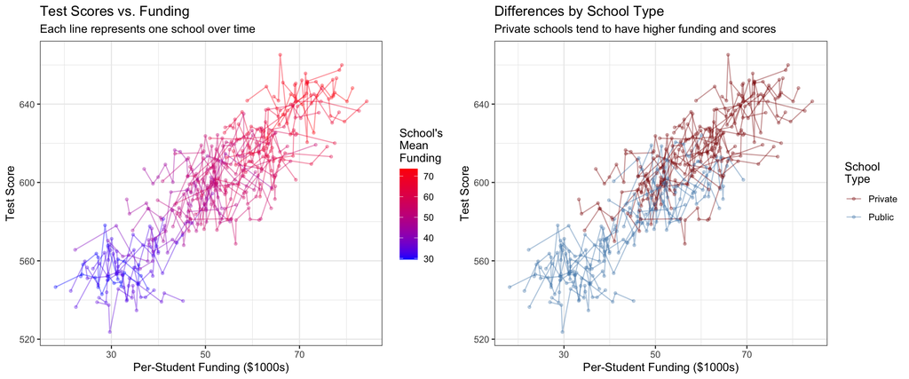

Figure 3: Structure of our panel data. Left: Each line represents one school’s trajectory over time, with colour indicating average funding level. Right: The same data distinguished by school type, showing that private schools (red) tend to have both higher funding and higher test scores.

```r
library(gridExtra)

# Calculate school-level summaries for colouring
school_summaries <- panel_data %>%
    group_by(school_id) %>%
    summarise(
        mean_funding = mean(funding),
        school_type = first(school_type)
    )

panel_data <- panel_data %>%
    left_join(school_summaries, by = "school_id")

# Create two plots
p1 <- ggplot(panel_data, aes(x = funding, y = test_score, group = school_id)) +
    geom_line(aes(colour = mean_funding), alpha = 0.4) +
    geom_point(aes(colour = mean_funding), alpha = 0.3, size = 1) +
    scale_colour_gradient(low = "blue", high = "red", name = "School's\nMean\nFunding") +
    labs(
        title = "Test Scores vs. Funding",
        subtitle = "Each line represents one school over time",
        x = "Per-Student Funding ($1000s)",
        y = "Test Score"
    ) +
    theme_bw()

p2 <- ggplot(panel_data, aes(x = funding, y = test_score, group = school_id)) +
    geom_line(aes(colour = school_type), alpha = 0.4) +
    geom_point(aes(colour = school_type), alpha = 0.3, size = 1) +
    scale_colour_manual(
        values = c("Public" = "steelblue", "Private" = "darkred"),
        name = "School\nType"
    ) +
    labs(
        title = "Differences by School Type",
        subtitle = "Private schools tend to have higher funding and scores",
        x = "Per-Student Funding ($1000s)",
        y = "Test Score"
    ) +
    theme_bw()

grid.arrange(p1, p2, ncol = 2)
```

OK so what are we actually looking at here?? This plot shows us the multi-level structure of our data. Within individual schools (along each line), test scores increase modestly with funding. Comparing across schools, those with higher average funding show substantially higher average scores. Additionally, private schools generally occupy the upper range of both funding and achievement. One can easily imagine how these simulated data could represent data found in the real world. Our modeling goal is to disentangle these relationships and understand what each level tells us about the role of funding and school type in student achievement.

## Fixed Effects Model

We begin with the fixed effects approach, which we would like to highlight is useful for it’s ability to control for all time-invariant confounding. Let’s fit the model!

### Fitting the Fixed Effects Model

The FE model uses the within transformation to eliminate all between-school variation, focusing exclusively on within-school changes over time. We fit this model using the `plm` package:

```r
# Fit fixed effects model
fe_model <- plm(
    test_score ~ funding,
    data = panel_pdata,
    model = "within"
)

# Display results
summary(fe_model)
```

```
Oneway (individual) effect Within Model

Call:
plm(formula = test_score ~ funding, data = panel_pdata, model = "within")

Balanced Panel: n = 40, T = 12, N = 480

Residuals:
     Min.   1st Qu.    Median   3rd Qu.      Max.
-24.73675  -4.97613   0.46135   4.73258  23.44846

Coefficients:
        Estimate Std. Error t-value  Pr(>|t|)
funding 0.620212   0.057637  10.761 < 2.2e-16 ***
---
Signif. codes:  0 '***' 0.001 '**' 0.01 '*' 0.05 '.' 0.1 ' ' 1

Total Sum of Squares:    28763
Residual Sum of Squares: 22760
R-Squared:      0.20871
Adj. R-Squared: 0.13661
F-statistic: 115.791 on 1 and 439 DF, p-value: < 2.22e-16
```

**What’s Happening Under the Hood 🚗**

You might notice that we didn’t create any dummy variables for schools in our model specification, yet we said that fixed effects models control for all time-invariant school characteristics. As a reminder, in the Within Transformation section, we discussed how this is operationalized.

When we specify `model = "within"` in the `plm()` function, the package automatically applies what’s called the **within transformation** (also known as **demeaning**). This transformation is mathematically equivalent to including dummy variables for each school, but much more computationally efficient.

Here’s what the within transformation does: for each school, it subtracts that school’s mean value from each observation. So our model becomes:

$$(y_{it} - \bar{y}_i) = \beta(x_{it} - \bar{x}_i) + (u_{it} - \bar{u}_i)$$

Notice that when we demean, any time-invariant school characteristic (the $\alpha_i$ term) disappears because $\alpha_i - \bar{\alpha}_i = \alpha_i - \alpha_i = 0$. This is exactly what including school dummy variables would accomplish—it removes all between-school variation and focuses only on within-school changes over time.

### Interpreting Fixed Effects Results

The coefficient on funding represents the within-school effect: when a school’s funding increases by one thousand dollars per student, its test scores increase by approximately 0.6 points (matching our simulated true effect). This estimate is consistent and unbiased because the within transformation has eliminated all confounding from time-invariant school characteristics.

```r
# Extract the coefficient and standard error
fe_coef <- coef(fe_model)["funding"]
fe_se <- sqrt(diag(vcov(fe_model)))["funding"]

# Construct 95% confidence interval
ci_lower <- fe_coef - 1.96 * fe_se
ci_upper <- fe_coef + 1.96 * fe_se

cat(sprintf(
    "Within-school effect of funding: %.3f (95%% CI: [%.3f, %.3f])\n",
    fe_coef, ci_lower, ci_upper
))
```

```
Within-school effect of funding: 0.620 (95% CI: [0.507, 0.733])
```

### Visualizing FE Estimates

Let’s further understand what the fixed effects model has done with a couple plots.

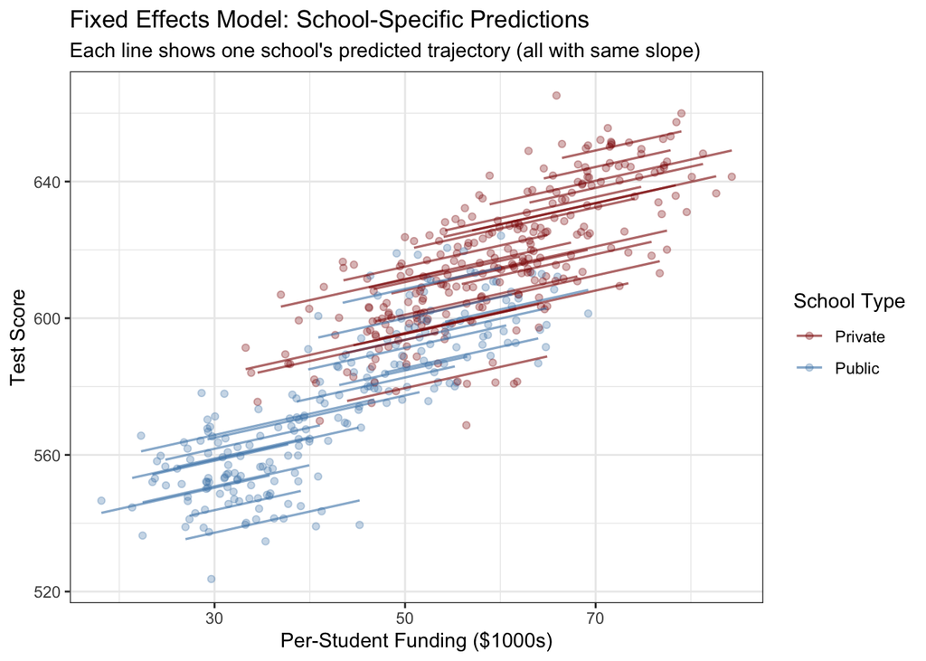

Figure 4: Fixed effects model fit. Each school gets its own fitted line (shown in colour), all sharing the same slope but with different intercepts that capture school-specific baseline differences.

```r
# Add fitted values to data
panel_data$fitted_fe <- predict(fe_model)

ggplot(panel_data, aes(x = funding, y = test_score)) +
    geom_point(aes(colour = school_type), alpha = 0.3, size = 1.5) +
    geom_line(aes(y = fitted_fe, group = school_id, colour = school_type),
        linewidth = 0.6, alpha = 0.6
    ) +
    scale_colour_manual(
        values = c("Public" = "steelblue", "Private" = "darkred"),
        name = "School Type"
    ) +
    labs(
        title = "Fixed Effects Model: School-Specific Predictions",
        subtitle = "Each line shows one school's predicted trajectory (all with same slope)",
        x = "Per-Student Funding ($1000s)",
        y = "Test Score"
    ) +
    theme_bw()
```

What we can see here perhaps most obviously are the parallel nature of the fixed effects model’s predictions. Every school gets its own baseline (intercept), but they all share the same slope—the within effect of funding.

### What Fixed Effects Cannot Tell Us

We’ve addressed the first level of the research question at hand, but there are other things we may wish to know with respect to this dataset.

**Three Things Fixed Effects Cannot Do**

**1. Estimate between-school effects**: We cannot answer “Do schools with higher average funding have higher average test scores?” The FE model has removed all between-school variation to control for confounding. In our data, the true between effect is 1.8 points per thousand dollars—three times larger than the within effect—but FE cannot estimate this.

**2. Estimate effects of time-invariant predictors**: We cannot answer “Do private schools perform differently than public schools?” The school type variable is time-invariant, so it is perfectly collinear with the school-specific intercepts and its effect cannot be identified. In our data, private schools score 10 points higher on average, but FE cannot estimate this.

**3. Make predictions for new schools**: If we wanted to predict test scores for a school not in our dataset, FE cannot help us. It provides no information about the distribution of school-specific intercepts or their relationship to school characteristics.

These are not minor technical limitations (and are certainly not specific to the package we’re using), they represent fundamental restrictions on the kinds of research questions FE models can address.

## REWB Model

Now we turn to the Random Effects Within-Between model, which can in theory address all three limitations of the fixed effects approach while not succumbing to heterogeneity bias. Let’s spend some time building this model up.

### Decomposing Within and Between Effects

First, let us fit a REWB model that decomposes funding into its within and between components. Once we do this, we can access both the within effect (which FE also gives us) and the between effect (which FE cannot estimate).

To fit this model, we need to create centered and mean variables:

```r
# Create within and between components of funding
library(magrittr)
library(dplyr)

panel_data_wb <- panel_data %>%
    dplyr::group_by(school_id) %>%
    dplyr::mutate(
        funding_mean = mean(funding), # Between component
        funding_centered = funding - funding_mean # Within component
    ) %>%
    dplyr::ungroup()
head(panel_data_wb)
```

```
# A tibble: 6 × 10
  school_id  year school_type.x funding test_score mean_funding school_type.y
  <fct>     <int> <fct>           <dbl>      <dbl>        <dbl> <fct>
1 1             1 Private          57.8       603.         51.8 Private
2 1             2 Private          56.9       599.         51.8 Private
3 1             3 Private          44.6       583.         51.8 Private
4 1             4 Private          61.7       596.         51.8 Private
5 1             5 Private          46.6       599.         51.8 Private
6 1             6 Private          51.2       589.         51.8 Private
# ℹ 3 more variables: fitted_fe <pseries>, funding_mean <dbl>,
#   funding_centered <dbl>
```

Now we fit the REWB model using `lmer()`. There are other options, but this is probably the most flexible approach for the linear case.

```r
# Fit basic REWB model (without school type)
rewb_model_basic <- lmer(
    test_score ~ funding_centered + funding_mean + (1 | school_id),
    data = panel_data_wb,
    REML = TRUE
)

# Display results
summary(rewb_model_basic)
```

```
Linear mixed model fit by REML ['lmerMod']
Formula: test_score ~ funding_centered + funding_mean + (1 | school_id)
   Data: panel_data_wb

REML criterion at convergence: 3384.3

Scaled residuals:
    Min      1Q  Median      3Q     Max
-3.4003 -0.6818  0.0707  0.6850  3.2918

Random effects:
 Groups    Name        Variance Std.Dev.
 school_id (Intercept) 98.00    9.9
 Residual              51.84    7.2
Number of obs: 480, groups:  school_id, 40

Fixed effects:
                  Estimate Std. Error t value
(Intercept)      486.89559    6.71201   72.54
funding_centered   0.62021    0.05764   10.76
funding_mean       2.13685    0.12588   16.98

Correlation of Fixed Effects:
            (Intr) fndng_c
fndng_cntrd  0.000
funding_men -0.971  0.000
```

To take a quick side-bar, to ensure it’s clear, let’s map what we just fit onto the mathematical framework from the methods section. Our formula:

```r
test_score ~ funding_centered + funding_mean + (1 | school_id)
```

corresponds directly to the statistical model:

$$y_{it} = \beta_0 + \beta_{1W}(x_{it} - \bar{x}_i) + \beta_{2B}\bar{x}_i + \alpha_i + \epsilon_{it}$$

With this formulation, we’re still accounting for the same response variable $y_{it}$ and funding covariate, but we’ve turned our covariate into the within-group component $(x_{it} - \bar{x_i})$ and the between-group component $\bar{x_i}$, which each get their own coefficient value. We’ve also now included the random intercept structure for the given schoool which is the time-invariant school-specific structure $\alpha_i$, which is in our equation as `(1|school_id)`. Recall that the error term is automatically included into models like this, we don’t specify it directly.

### Interpreting Within and Between Effects

The REWB model now provides two distinct pieces of information:

```r
# Extract coefficients
within_coef <- fixef(rewb_model_basic)["funding_centered"]
between_coef <- fixef(rewb_model_basic)["funding_mean"]

# Extract standard errors
se <- sqrt(diag(vcov(rewb_model_basic)))
within_se <- se["funding_centered"]
between_se <- se["funding_mean"]

# Create a results data frame
rewb_results <- data.frame(
    Effect = c("Within-school", "Between-school"),
    Estimate = c(within_coef, between_coef),
    SE = c(within_se, between_se),
    Interpretation = c(
        "When a school's funding increases by $1000, test scores increase by this amount",
        "Schools with $1000 higher average funding score this much higher on average"
    )
)

# Print formatted table
knitr::kable(rewb_results,
    digits = 3,
    col.names = c("Effect Type", "Estimate", "Std. Error", "Interpretation")
)
```

|  | Effect Type | Estimate | Std. Error | Interpretation |
| --- | --- | --- | --- | --- |
| funding_centered | Within-school | 0.620 | 0.058 | When a school’s funding increases by $1000, test scores increase by this amount |
| funding_mean | Between-school | 2.137 | 0.126 | Schools with $1000 higher average funding score this much higher on average |

We can test whether these effects differ significantly. This is essentially a Wald test asking whether $\beta_{1W} = \beta_{2B}$. We compute the difference between the coefficients, calculate its standard error (using the formula for the variance of a difference of independent estimates), and construct a test statistic that we can assess:

```r
# Test whether within and between effects differ
diff <- between_coef - within_coef
diff_se <- sqrt(within_se^2 + between_se^2)
z_stat <- diff / diff_se
p_value <- 2 *
    (1 - pnorm(abs(z_stat)))
cat(p_value)
```

```
0
```

The results show that the within and between effects are significantly different (*p* < 0.001), confirming that changes in funding within schools (the within effect) have a much smaller association with test scores than differences in average funding levels between schools (the between effect). This demonstrates why it’s important to model these relationships separately rather than assuming they are the same.

### Visualizing Within and Between Effects

Let’s visualize what the REWB model has estimated. We’ll show both the within-school relationships (individual school trajectories) and the between-school relationship (how average funding relates to average test scores):

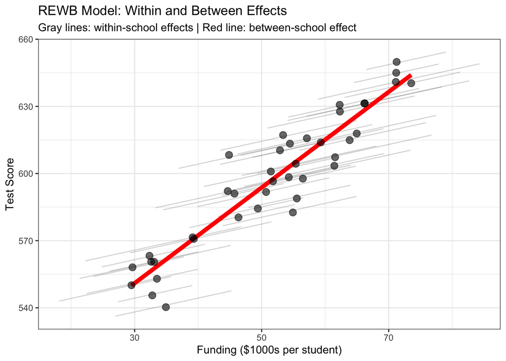

Figure 5: REWB model showing within-school (gray lines) and between-school (thick red line) effects. The modest slopes of individual school lines represent the within effect, while the steeper red line shows the stronger between-school relationship.

```r
# Generate fitted values for within-school relationships
panel_data$fitted_rewb_basic <- fitted(rewb_model_basic)

# For between-school relationship, create predictions at school means
school_means <- panel_data_wb %>%
    group_by(school_id) %>%
    summarise(
        funding_mean = first(funding_mean),
        test_score_mean = mean(test_score),
        school_type = first(school_type)
    )

# Generate population-level predictions for between effect
funding_range <- seq(min(school_means$funding_mean),
    max(school_means$funding_mean),
    length.out = 100
)
between_pred <- predict(
    rewb_model_basic,
    newdata = data.frame(
        funding_centered = 0,
        funding_mean = funding_range,
        school_id = NA
    ),
    re.form = NA
)

between_line <- data.frame(
    funding_mean = funding_range,
    test_score = between_pred
)

# Create visualization
ggplot() +
    # Within-school fitted lines
    geom_line(
        data = panel_data,
        aes(x = funding, y = fitted_rewb_basic, group = school_id),
        alpha = 0.3, colour = "gray50", linewidth = 0.5
    ) +
    # Between-school relationship (thick red line)
    geom_line(
        data = between_line,
        aes(x = funding_mean, y = test_score),
        colour = "red", linewidth = 2
    ) +
    # School means as points
    geom_point(
        data = school_means,
        aes(x = funding_mean, y = test_score_mean),
        size = 3, alpha = 0.6
    ) +
    labs(
        title = "REWB Model: Within and Between Effects",
        subtitle = "Gray lines: within-school effects | Red line: between-school effect",
        x = "Funding ($1000s per student)",
        y = "Test Score"
    ) +
    theme_bw()
```

This visualization shows (quite elegantly) what we’ve gained by using REWB instead of FE. The gray lines show the within effect that fixed effects also estimates—modest changes within schools as funding varies. But now we also see the red line showing the much stronger between-school relationship: schools with higher average funding score substantially higher overall.

### Adding Time-Invariant Predictors

Now let’s extend to demonstrate the second major advantage of REWB, which is to estimate effects of time-invariant predictors. We add school type to our model:

```r
# Fit full REWB model including school type
rewb_model_full <- lmer(
    test_score ~ funding_centered + funding_mean + school_type + (1 | school_id),
    data = panel_data_wb,
    REML = TRUE
)

# Display results
summary(rewb_model_full)
```

```
Linear mixed model fit by REML ['lmerMod']
Formula: test_score ~ funding_centered + funding_mean + school_type +
    (1 | school_id)
   Data: panel_data_wb

REML criterion at convergence: 3372.8

Scaled residuals:
    Min      1Q  Median      3Q     Max
-3.3895 -0.6829  0.0587  0.6723  3.3026

Random effects:
 Groups    Name        Variance Std.Dev.
 school_id (Intercept) 83.20    9.121
 Residual              51.84    7.200
Number of obs: 480, groups:  school_id, 40

Fixed effects:
                   Estimate Std. Error t value
(Intercept)       506.93946    9.62356  52.677
funding_centered    0.62021    0.05764  10.761
funding_mean        1.84541    0.15807  11.675
school_typePublic -11.00334    4.03705  -2.726

Correlation of Fixed Effects:
            (Intr) fndng_c fndng_m
fndng_cntrd  0.000
funding_men -0.978  0.000
schl_typPbl -0.764  0.000   0.676
```

We can see here the same output but with our added component.

**What Model is this Estimating?**

Our model formula:

```r
test_score ~ funding_centered + funding_mean + school_type + (1 | school_id)
```

should now map somewhat intuitively to the statistical model:

$$y_{it} = \beta_0 + \beta_{1W}(x_{it} - \bar{x}_i) + \beta_{2B}\bar{x}_i + \beta_3 z_i + \alpha_i + \varepsilon_{it}$$

where $z_i$ is the school type variable (Public or Private) and $\alpha_i \sim N(0, \sigma^2_{\alpha})$ represents random school-specific deviations.

### Interpreting the School Type Effect

So what we have now is a time-invariant effect of school type on our outcome variable of interest. Let’s examine what we’ve estimated:

```r
# Create a summary table of all effects
coef_summary <- data.frame(
    Effect = c("Within (Funding)", "Between (Funding)", "School Type (Private vs Public)"),
    Estimate = c(
        fixef(rewb_model_full)["funding_centered"],
        fixef(rewb_model_full)["funding_mean"],
        fixef(rewb_model_full)["school_typePublic"]
    ),
    `Std. Error` = sqrt(diag(vcov(rewb_model_full)))[c("funding_centered", "funding_mean", "school_typePrivate")],
    `True Value` = c(0.600, 1.800, 10.00),
    check.names = FALSE
)

knitr::kable(coef_summary,
    digits = 3,
    caption = "Full REWB Model: All Fixed Effects"
)
```

Full REWB Model: All Fixed Effects

|  | Effect | Estimate | Std. Error | True Value |
| --- | --- | --- | --- | --- |
| funding_centered | Within (Funding) | 0.620 | 0.058 | 0.6 |
| funding_mean | Between (Funding) | 1.845 | 0.158 | 1.8 |
| school_typePublic | School Type (Private vs Public) | -11.003 | NA | 10.0 |

Private schools score approximately 10 points higher than public schools, even after controlling for both within-school funding changes and between-school funding differences. This represents the independent contribution of school type—perhaps reflecting differences in selectivity, resources, or educational approaches that aren’t captured by funding alone.

Let’s verify that adding school type hasn’t substantially changed our funding effects:

```r
# Compare funding effects across models
funding_comparison <- data.frame(
    Effect = c("Within Effect", "Between Effect"),
    `Basic Model` = c(
        fixef(rewb_model_basic)["funding_centered"],
        fixef(rewb_model_basic)["funding_mean"]
    ),
    `With School Type` = c(
        fixef(rewb_model_full)["funding_centered"],
        fixef(rewb_model_full)["funding_mean"]
    ),
    Change = c(
        fixef(rewb_model_full)["funding_centered"] - fixef(rewb_model_basic)["funding_centered"],
        fixef(rewb_model_full)["funding_mean"] - fixef(rewb_model_basic)["funding_mean"]
    ),
    check.names = FALSE
)

knitr::kable(funding_comparison,
    digits = 3,
    caption = "Stability of Funding Effects After Adding School Type"
)
```

Stability of Funding Effects After Adding School Type

|  | Effect | Basic Model | With School Type | Change |
| --- | --- | --- | --- | --- |
| funding_centered | Within Effect | 0.620 | 0.620 | 0.000 |
| funding_mean | Between Effect | 2.137 | 1.845 | -0.291 |

### Visualizing the Complete Model

Finally, let’s create a visualization that shows all three effects estimated by our full REWB model:

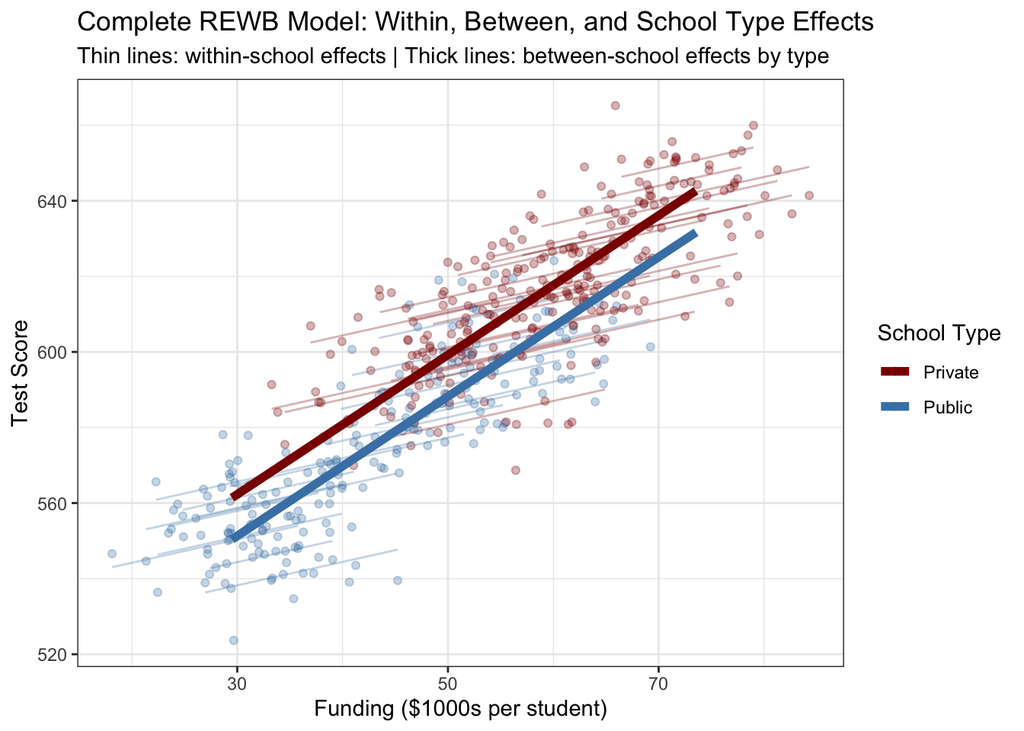

Figure 6: Complete REWB model showing within effects (school-specific lines), between effects (parallel to population lines), and school type differences (vertical separation between public and private schools).

```r
# Generate fitted values
panel_data_wb$fitted_rewb_full <- fitted(rewb_model_full)

# Create separate between lines for public and private schools
between_lines <- expand.grid(
    funding_mean = seq(min(school_means$funding_mean),
        max(school_means$funding_mean),
        length.out = 100
    ),
    school_type = factor(c("Public", "Private"))
)

between_lines$test_score <- predict(
    rewb_model_full,
    newdata = data.frame(
        funding_centered = 0,
        funding_mean = between_lines$funding_mean,
        school_type = between_lines$school_type,
        school_id = NA
    ),
    re.form = NA
)

# Create visualization
ggplot() +
    geom_point(
        data = panel_data_wb,
        aes(x = funding, y = test_score, colour = school_type),
        alpha = 0.3
    ) +
    # Within-school fitted lines (coloured by type)
    geom_line(
        data = panel_data_wb,
        aes(x = funding, y = fitted_rewb_full, group = school_id, colour = school_type),
        alpha = 0.3, linewidth = 0.5
    ) +
    # Between-school relationships (thick lines by type)
    geom_line(
        data = between_lines,
        aes(x = funding_mean, y = test_score, colour = school_type),
        linewidth = 2
    ) +
    scale_colour_manual(
        values = c("Public" = "steelblue", "Private" = "darkred"),
        name = "School Type"
    ) +
    labs(
        title = "Complete REWB Model: Within, Between, and School Type Effects",
        subtitle = "Thin lines: within-school effects | Thick lines: between-school effects by type",
        x = "Funding ($1000s per student)",
        y = "Test Score"
    ) +
    theme_bw() +
    theme(legend.position = "right")
```

# Frequently Asked Questions

This section addresses common questions that arise when implementing panel data models. We’ve organized these roughly from basic implementation questions to more advanced modeling considerations.

#### **How many time periods do I need?**

The minimum is two time periods—otherwise you don’t have panel data! However, more periods are strongly recommended, particularly for within-group effects. With only two periods, within-group estimates are based on a single difference for each unit, making them sensitive to measurement error and transitory shocks. With 4-5 or more periods, you have multiple within-unit observations that provide much more stable estimates. However, this is still the rough “minimum”.

#### **What if my panel is unbalanced?**

These models handle unbalanced panels naturally—units can have different numbers of observations without requiring any special treatment. The estimation procedures automatically account for this. However, you should investigate *why* your panel is unbalanced. If observations are missing at random (for example, some surveys were randomly not conducted in certain years), this typically poses no problems. If missingness is related to the outcome or predictors (for example, low-performing schools systematically drop out of the study), you may have selection bias that neither FE nor REWB can address without additional modeling assumptions.

#### **Can I use these methods with binary or count outcomes?**

Yes, but with some important caveats. For fixed effects with non-continuous outcomes, you need specialized estimators: conditional logit for binary outcomes, conditional Poisson for counts. These are available in most statistical packages but have some limitations compared to the linear case. For REWB models, you use generalized linear mixed models (GLMMs): logistic regression with random effects for binary outcomes, Poisson or negative binomial with random effects for counts. As discussed in the Bell and Jones (2015) paper we referenced earlier, the REWB decomposition in GLMMs doesn’t perfectly eliminate all between-unit confounding (unlike in the linear case), but simulations suggest the bias is typically modest. The advantage of REWB—allowing time-invariant predictors and variance components—often outweighs this small potential for bias.

#### **What about three-level data structures?**

Not a big deal! For example, with students nested in classrooms nested in schools, you might have time-varying predictors at the student level, which can be decomposed into within-student, within-classroom (between-student), and between-classroom components. The `lme4` package in R handles such structures with formulas we’ve not covered here, but there is ample documentation for, like `(1 | school_id/classroom_id)` for nested random effects.

### What if my treatment variable barely varies within units?

This is a serious challenge for these models, and ultiamtely is a question for a power analysis. If you’re trying to measure a very small effect, you will need sufficiently large amounts of data to find it.

### Can’t I just use pooled OLS and ignore the panel structure?

You could, but you almost certainly shouldn’t. Pooled OLS treats all observations as independent, which means:

1. **Biased coefficients**: If there are time-invariant confounders correlated with your predictors (heterogeneity bias), your estimates will be biased. This is the fundamental problem that both FE and REWB address.
2. **Wrong standard errors**: Even if coefficients happen to be unbiased, your standard errors will be too small because OLS doesn’t account for within-unit correlation. Your confidence intervals and p-values will be misleading.
3. **You’re possibly posing the wrong answers to your questions**: You can’t distinguish within from between effects, which are often substantively different and interesting.

The minimal responsible approach is to at least use cluster-robust standard errors with pooled OLS, but even this doesn’t solve the bias problem. Unless you have strong theoretical reasons to believe there is no heterogeneity bias and no interesting difference between within and between effects, use one of these approaches.

### What about random slopes? When should I allow effects to vary across units?

This is an important extension we mentioned earlier but didn’t implement in our main examples. Random slopes allow the effect of a predictor to vary across higher-level units. In our school funding example, this would mean allowing the within-school effect of funding to differ from school to school—perhaps funding is more effective in some schools than others.

**When to consider random slopes:**

1. You have theoretical reasons to expect heterogeneous effects (e.g., policies might work differently in different contexts)
2. Your outcome shows different slopes across groups in exploratory plots
3. You want to test whether a group-level variable moderates a lower-level effect

**You could implement this easily with:**

In `lme4`, change `(1 | school_id)` to `(1 + funding_centered | school_id)`. This allows both intercepts and the effect of centered funding to vary across schools. Be aware that this substantially increases model complexity—you’re now estimating the variance of the slopes and their covariance with the intercepts.

**Important consideration:**

It is definitely true that failing to include random slopes when they exist can lead to anti-conservative standard errors (confidence intervals that are too narrow). If you have a key predictor where heterogeneous effects are plausible, it’s worth testing whether allowing random slopes substantially changes your inferences. However, random slopes require sufficient data—you need enough within-unit observations to reliably estimate unit-specific slopes. With only 2-3 time points per unit, random slopes models often fail to converge or produce unreliable estimates.

### Should I test whether within and between effects are different?

A common question is whether one should always include both within and between components in the model. The answer depends on your research question and the data. If $\beta_W = \beta_B$, then the simpler standard RE model (which constrains them to be equal) may be adequate. However, we recommend starting with the REWB specification as the default, since you can then just formally test the hypothesis.

## References

Bates, D, M Machler, B Bolker, and Steven C Walker. 2014. “Fitting Linear Mixed-Effects Models Using lme4.” *Journal of Statistical Software* 67 (June): 1–48. https://doi.org/10.18637/JSS.V067.I01.

Bell, Andrew, and Kelvyn Jones. 2015. “Explaining Fixed Effects: Random Effects Modeling of Time-Series Cross-Sectional and Panel Data.” *Political Science Research and Methods* 3 (January): 133–53. https://doi.org/10.1017/psrm.2014.7.

Croissant, Yves, and Giovanni Millo. 2008. “Panel Data Econometrics inR: TheplmPackage.” *Journal of Statistical Software* 27. https://doi.org/10.18637/jss.v027.i02.

Fielding, A. 2004. “The Role of the Hausman Test and Whether Higher Level Effects Should Be Treated as Random or Fixed.” *Multilevel Modelling Newsletter* 16: 3–9.

Hausman, J A. 1978. “Specification Tests in Econometrics.” *Econometrica: Journal of the Econometric Society* 46 (November): 1251. https://doi.org/10.2307/1913827.

Mundlak, Yair. 1978. “On the Pooling of Time Series and Cross Section Data.” *Econometrica: Journal of the Econometric Society* 46 (January): 69. https://doi.org/10.2307/1913646.

## Footnotes

[^1]: Repeated observations of the same grouping groups over time
[^2]: A within-group effect captures how changes in a predictor relate to changes in an outcome within the same group over time, isolating stable between-group differences.
[^3]: A between-group effect captures how the average levels of a predictor relate to average levels of an outcome when comparing across groups and whether groups with higher mean predictor values across *all time periods* also exhibit higher mean outcome values, which would represent a stable difference between groups.
[^4]: observations within the same group are correlated with one another, which violates the independence assumption required for standard regression methods
[^5]: With respect to a variable, it can be said that if that particular variable is independent of other variables in the system, defined as $\text{Cov}(\mathbf{x_{it}}, \alpha_i) = 0$, then it has **no** heterogeneity bias.